# TP2 de MPA

Clément MALLERET, Alexis SONOLET

##Question 1

$$c = 1 \implies \theta_1 = \theta_2 \\
\implies \forall 1 \leq i \leq n : p(y_i | c = 1, \theta_2, \theta_2) = p(y_i | \theta_2) = \theta_2^{y_i}(1-\theta_2)^{1 - y_i} \\$$

Ainsi, les émissions étant indépendantes, on a :
$$p(y|c=1) = p(y_1, \dots, y_n) = p(y_1) \dots p(y_n) = \prod_{i=1}^n \theta_2^{y_i}(1-\theta_2)^{1 - y_i}$$

##Question 2

Par indépendances des $y_i$ comme précédemment :
$$p(y|c) = \prod_{i=1}^{c-1} p(y_i) \times \prod_{i = c}^{n} p(y_i)\\
=\prod_{i=1}^{c-1} \theta_1^{y_i}(1-\theta_1)^{1 - y_i} \times \prod_{i = c}^{n}\theta_2^{y_i}(1-\theta_2)^{1 - y_i} \\$$

##Question 3

$$\dfrac{p(c|y)}{p(c=1 | y)} = \dfrac{p(y|c)p(c)p(y)}{p(y|c=1)p(c=1)p(y)}$$

Or :
$$p(c) = \dfrac{1}{np(\theta_1)p(\theta_2)} = p(c=1)$$
car $\theta_1, theta_2$ connus donc fixes.

On a donc :

$$\dfrac{p(c|y)}{p(c=1 | y)} = \dfrac{p(y|c)}{p(y|c=1)} = \prod_{i=1}^{c-1} \dfrac{\theta_1^{y_i}(1-\theta_1)^{1 - y_i}}{\theta_2^{y_i}(1-\theta_2)^{1 - y_i}}$$

Coût en calculs : Pour c quelconque, on effectue un produit de $c-1$ termes. Chaque terme ne peut prendre que deux valeurs : $\dfrac{\theta_1}{\theta_2}$ si $y_i = 1$, $\dfrac{(1 - \theta_1)}{(1-\theta_2)}$ sinon : on précalculera donc ces deux valeurs. Ainsi, le coût de calcul d’un terme du produit est de 1 (choix du terme suivant la valeur de $y_i$) Le coût de calcul pour $c$ entre $2$ et $n$ est donc de $c-1$ multiplications. Pour $c=1$, le rapport vaut 1 : on n’a pas de multiplications. On fait le calcul pour $c$ allant de $1$ à $n$ : on a donc au total $0 + \sum_{c=2}^n (c-1) = \dfrac{n(n-1)}{2}$

##Question 4

On a $\theta_1$, $\theta_2$ connues. On commence par calculer tous les rapports $\dfrac{p(c|y)}{p(c=1|y)} \forall c \geq 2$. On peut faire cette étape en $O(n)$ car :

$$\dfrac{p(c=i+1|y)}{p(c=1|y)} = \dfrac{p(c=i|y)}{p(c=1|y)} \times \dfrac{\theta_1^{y_i}(1-\theta_1)^{1-y_i}}{\theta_2^{y_i}(1-\theta_2)^{1-y_i}}$$
Une fois cette étape passée, on calcule p(c=1|y). Pour cela, on résout le système suivant :
$$p(c=1|y) = 1 - p(c=1|y) \times \sum_{i=2}^n \dfrac{p(c=i|y)}{p(c=1|y)} \\
\Leftrightarrow p(c=1|y) = \dfrac{1}{1+\sum_{i=2}^n \dfrac{p(c=i|y)}{p(c=1|y)}}$$
Le calcul de la somme est en $O(n)$ : on est toujours en $O(n)$. Ayant maintenant $p(c=1|y)$, on multiplie tous les rapports $\dfrac{p(c|y)}{p(c=1|y)}$ par $p(c=1|y)$ (en $O(n)$) : on a désormais calculé tous les $p(c|y)$ en $O(n)$.

Implémentation :

```r
#entrée : vecteur y de taille n, theta1, theta2
#sortie : vecteur des p(c|y) de taille n
calcul_pc <- function(y, theta1, theta2){
    p_c = c(1)
    n = length(y)
    if (theta2 == 0){ #on évite les cas ou theta2 = 0 ou 1 (division par 0)
      rapport_theta_0 = theta1/0.0001
    }
    else{
      rapport_theta_0 = theta1/theta2
    }

    if (theta2 == 1){
      rapport_theta_1 = theta1/0.0001
    }
    else{
      rapport_theta_1 = (1 - theta1) / (1 - theta2)
    }

    #on calcule les rapports :
    #initialisation
    if (y[1] == 1){
        p_actuel = rapport_theta_0
    }
    else{
        p_actuel = rapport_theta_1
    }
    p_c = c(p_c, p_actuel)

    #iteration
    for (i in 3:n){
        if (y[i-1] == 1){
            p_actuel = p_actuel * rapport_theta_0
        }
        else{
            p_actuel = p_actuel * rapport_theta_1
        }
        p_c = c(p_c, p_actuel)

    }

    #on calcule p(c=1)
    p_c_1 = 1 / (sum(p_c)) #et non 1 + somme car on a initialisé p(c=1) a 1.

    #on multiplie tout le vecteur par p(c=1|y) :
    p_c = p_c_1 * p_c
    return(p_c)
}
```

##Question 5

```r
#On simule c à partir de theta1, theta2, y grace à l'algorithme de rejet

simulation_c <- function(y, theta1, theta2){
  n = length(y)
  p_c = calcul_pc(y, theta1, theta2)

  #initialisation
  c_simule = sample(1:n, 1)
  x = runif(1)

  #boucle
  while(x > p_c[c_simule]){
    c_simule = sample(1:n, 1)
    x = runif(1)
  }
  return(c_simule)
}
```

```r
#On simule des valeurs de theta a partir de c avec la loi beta

simulation_theta <- function(y,c){
  n = length(y)
  nb_1_avant_c = sum(y[1:c-1])
  nb_1_apres_c = sum(y[c:n])

  theta1 = rbeta(1, nb_1_avant_c + 1, c - nb_1_avant_c)
  theta2 = rbeta(1, nb_1_apres_c + 1, (n - c) + 1 - nb_1_apres_c)

  return(c(theta1, theta2))
}
```

#algo de Gibbs

```r
gibbs <-function(y) {
  #On choisit des theta1, theta2 quelconques
  theta1 = 0.5 #runif(1)
  theta2 = 0.5 #runif(1)

  c = simulation_c(y, theta1, theta2)

  for (i in 1:2000){
    theta = simulation_theta(y, c)
    theta1 = theta[1]
    theta2 = theta[2]
    c = simulation_c(y, theta1, theta2)
  }

  #On fait une dernière itération
  theta = simulation_theta(y, c)
  theta1 = theta[1]
  theta2 = theta[2]

  #on récupère les probabilités de c=i pour tout i
  pc = calcul_pc(y, theta1, theta2)

  c = simulation_c(y, theta1, theta2)
  return(list(pc, theta1, theta2, c))
}
```

##Question 6

##Question 7

```r
quartile <- function(y) {
  n = length(y)
  acc = 0
  premier_quartile_fait = FALSE
  quartiles = c()

  for (i in 1:n){
    acc = acc + y[i]
    if (acc > 0.25 && !premier_quartile_fait){
      premier_quartile_fait = TRUE
      quartiles = c(quartiles, i-1)
    }
    if (acc > 0.75){
      quartiles = c(quartiles, i)
      return(quartiles)
    }
  }
}
```

```r
#On importe les données
echantillon1 = scan("echantillon1.txt")
echantillon2 = scan("echantillon2.txt")
```

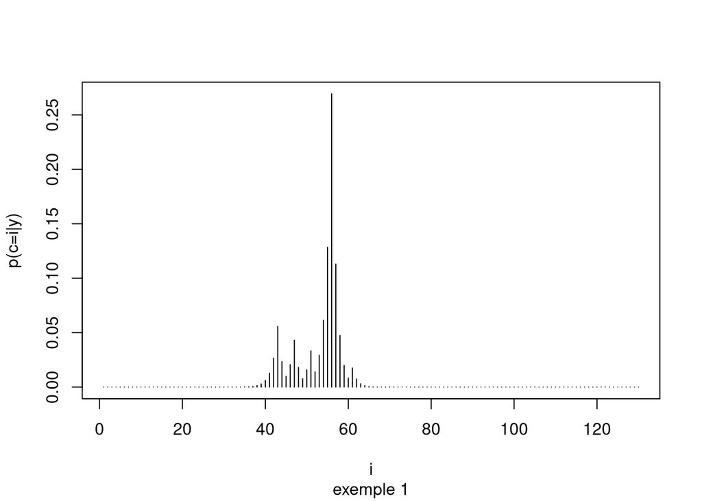

|  | theta1 | theta2 | c | premier_quartile | troisieme_quartile |
| --- | --- | --- | --- | --- | --- |
| exemple 1 | 0.2741539 | 0.653633 | 56 | 50 | 56 |

```r
affiche_resultats <- function(y, nom){
  a = gibbs(y)
  #affichage des probabilités de c=i pour tout i
  pc <- a[[1]]
  plot(pc, type = "h", xlab = "i", sub = nom, ylab = "p(c=i|y)")

  #on récupère theta1, theta 2, c
  theta1 = a[[2]]
  theta2 = a[[3]]
  c = a[[4]]

  #on calcule les bornes de l'intervalle centré dans lequel c à 50% de chances de se trouver
  quartiles = quartile(pc)
  premier_quartile = quartiles[1]
  troisieme_quartile = quartiles[2]

  #on affiche le tout dans un joli tableau
  tableau = data.frame(theta1, theta2, c, premier_quartile, troisieme_quartile, row.names = nom)

  tableau

}
affiche_resultats(echantillon1, "exemple 1")
```

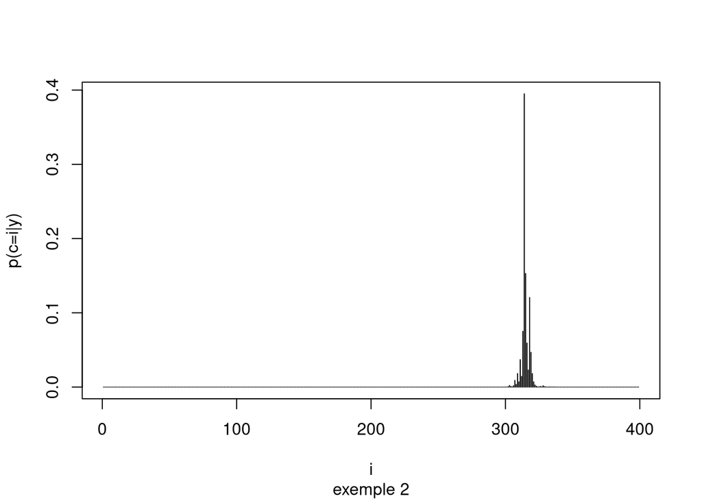

|  | theta1 | theta2 | c | premier_quartile | troisieme_quartile |
| --- | --- | --- | --- | --- | --- |
| exemple 2 | 0.3384958 | 0.8742622 | 312 | 313 | 316 |

```r
affiche_resultats(echantillon2, "exemple 2")
```